# Checkpoint 3

## 1. Visão Geral

Estamos no Checkpoint 3, em nosso primeiro laboratório, e para tanto vamos responder duas perguntas acerca de nosso conjunto de dados, descrevendo-as e fazendo discusões a partir das conclusões.

Nessa análise vamos continuar utilizando dos dados do [IMDB](https://www.imdb.com/) sobre seriados de TV. Neste [repositório](https://github.com/nazareno/imdb-series), encontram-se todos os dados e variáveis necessarios para essa análise.

## 2. Carregando conjunto de dados

```r
series = read_csv(here("data/series_from_imdb.csv"),
                  progress = FALSE,
                  col_types = cols(.default = col_double(),
                                   series_name = col_character(),
                                   episode = col_character(),
                                   url = col_character(),
                                   season = col_character()))
```

## 3. Perguntas

### 3.1 Pergunta 1 - Quais séries possuem maior diferença entre notas de avaliações por temporadas?

Para responder essa pergunta precisamos criar duas novas variáveis em nosso conjunto de dados, a saber, `season_average` e `season_rating_dist`, que irão definir a média de avaliação e a diferença absoluta entre a maior e a menor nota de avaliação por temporada para cada serie, respectivamente. Com essas variáveis pretendo análisar as diferenças de avaliações para todo o conjunto de series, observando as frequências das médias de avaliação.

#### 3.1.1 Agrupandos os dados

```r
series = series %>%
    group_by(series_name, season, user_votes)
```

#### 3.1.2 Resumindo os dados

Aqui, resumimos nossa tabela de dados acerca das variáveis que pretendemos definir e análisar.

```r
series = series %>%
    summarize(
        season_average = mean(user_rating),
        season_rating_dist = max(user_rating) - min(user_rating),
        season_size = n())

series %>%
    select(series_name, season_average, season_rating_dist) %>%
    arrange(season_rating_dist, -season_average)
```

| season | series_name | season_average | season_rating_dist |
| --- | --- | --- | --- |
| 5 | Arrow | 9.9 | 0 |
| 4 | Breaking Bad | 9.9 | 0 |
| 5 | Breaking Bad | 9.9 | 0 |
| 5 | Breaking Bad | 9.9 | 0 |
| 3 | Game of Thrones | 9.9 | 0 |
| 5 | Game of Thrones | 9.9 | 0 |
| 6 | Game of Thrones | 9.9 | 0 |
| 6 | Game of Thrones | 9.9 | 0 |
| 2 | Hannibal | 9.9 | 0 |
| 4 | Person Of Interest | 9.9 | 0 |

[output cut: 9990 more lines]

#### 3.1.3 Gráfico 1 - Analisando média e diferenças das notas de avaliações

Para essa visualização, escolhi apresentar os dados como se segue, com um conjunto de hexagonos que agrupam series a partir da variável `season_rating_dist`. Além disso, pode-se visualizar a contagem/frequência de series que possuem diferença entre maior e menor nota próximas ou distantes.

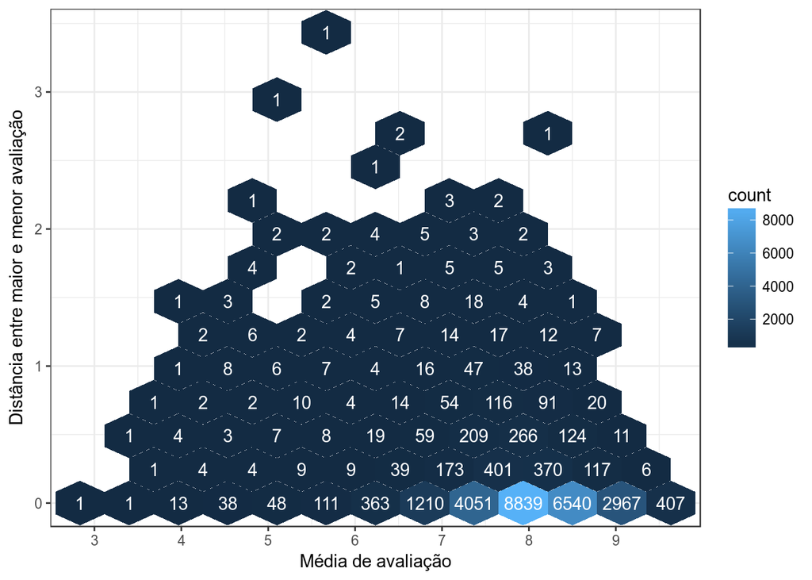

```r
ggplot(series, aes(x = season_average, y = season_rating_dist)) +
    geom_hex(bins=12) +
    stat_binhex(aes(label=..count..), geom="text", bins=12, colour="white") +
    scale_x_continuous(breaks = seq(0, 10, 1)) +
    labs(x = "Média de avaliação",
         y = "Distância entre maior e menor avaliação")
```